# Biến môi trường (Environment Variables)

**Biến môi trường** là một kiến thức quan trọng cho thực hiện một dựa án có chứa các thông tin quan trọng nhạy cảm như API Key, ID, Mật khẩu,... Việc thiết lập biến môi trường giá trị chỉ ở trong máy mà không lan truyền ra ngoài, tăng cường khả năng bảo mật.

Có 2 các chính:

- Tạo biến môi trường lưu trong windows
- dùng file `.env` (Local Environment File)

## Tạo biến môi trường trong Windows

1. Tìm `Environment Variables` trong thanh tìm kiếm → chọn `Edit the system environment variables`.

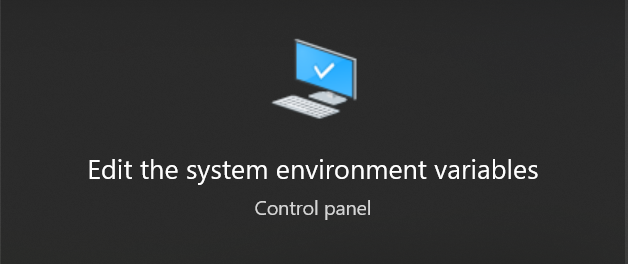

2. Trong hộp thoại `System Properties` → `Tab Advanced` → Bấm nút `Environment Variables`.

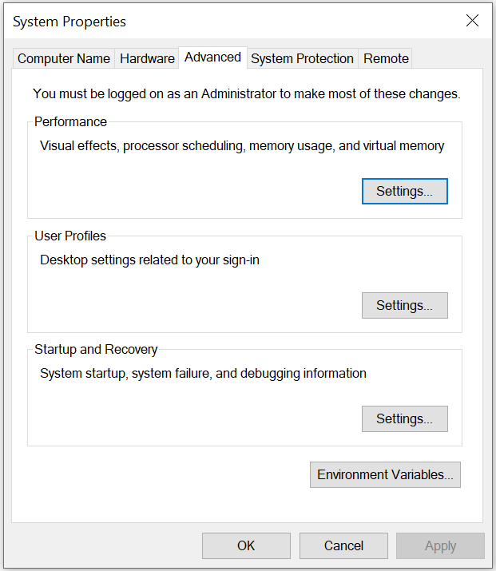

3. Nhấn `New` tại `User variables` để tạo biến môi trường, nhập tên biến và giá trị.

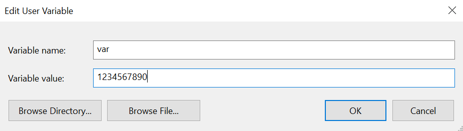

```python
# Sử dụng biến môi trường
import os

# os.environ['var'] = '1234567890'

env = os.getenv('var')
print(env)
```

```
1234567890
```

Có thể kiểm tra xem biến môi trường đã có trong hệ thống chưa bằng Command Prompt với lệnh `echo %var%`. Kết quả sẽ trả về giá trị đã được đặt trong hệ thống.

## Sử dụng file `.env` (file chứa biến môi trường)

`.env` file chứa biến môi trường tùy chỉnh cho mỗi dự án, không cần cài đặt trong hệ thống. Giúp quản lý linh hoạt hơn và tùy biến cho từng dự án.

Kết hợp cùng `.gitignore` và thư viện (`python-dotenv & os`) để quản lý các biến môi trường.

1. `Tạo file .env`
2. Dùng thư viện để gọi file `.env` và lấy giá trị

```python
# pip install python-dotenv
```

```python
env = """
API_KEY=your_api_key_123456
DATABASE_PASSWORD=your_db_password_abcdef
SECRET_TOKEN=my_secret_token_7890
"""

with open('.env', 'w') as f:
    f.write(env.strip())

print("Đã tạo file .env")
```

```
Đã tạo file .env
```

```python
from dotenv import load_dotenv
import os

load_dotenv()  # Tự động đọc file .env cùng thư mục với notebook

# Lấy biến môi trường ra sử dụng
api_key = os.getenv('API_KEY')
db_password = os.getenv('DATABASE_PASSWORD')
secret_token = os.getenv('SECRET_TOKEN')

print("API_KEY:", api_key)
print("DATABASE_PASSWORD:", db_password)
print("SECRET_TOKEN:", secret_token)
```

```
API_KEY: your_api_key_123456
DATABASE_PASSWORD: your_db_password_abcdef
SECRET_TOKEN: my_secret_token_7890
```

Khi push code lên dự án lên git, để không chuyển file `.env` lên repo của dựa án cần tạo 1 file `.gitignore` và thêm file `*.env` vào. git sẽ không thêm file này lên repo.